# BIS 620 Final Project

Author

Anmol Seth, anmol.seth@yale.edu; Julia Stiller, julia.stiller@yale.edu

Data Source: ([NCT00364013](https://clinicaltrials.gov/ct2/show/NCT00364013?term=NCT00364013&draw=2&rank=1)).

## Prepare Environment and Data set

```r
library(haven)
library(purrr)
library(dplyr)
library(ggplot2)
library(knitr)
library(survival)
library(survminer)

source("get_genotype.R")

trial_path = file.path("..", "Final Project", "NCT00364013")
trial_files = list.files(trial_path, pattern = "*_pds2019.sas7bdat")

dl = map(file.path(trial_path, trial_files), ~ read_sas(.x))
names(dl) = gsub("*_pds2019.sas7bdat", "", trial_files)

# Read in required data
adae = dl$adae #contains adverse events
adsl = dl$adsl #contains subject-level data
biomark = dl$biomark #contains biomarkers

# Select columns relevant to analysis
filtered_biomark <- biomark %>%
  select(c(1:7, 16:17))

# Utilize our get_genotype() function on each subject ID
filtered_biomark$Genotype <- sapply(filtered_biomark$SUBJID, get_genotype)

# Create master table by joining biomarker data with treatment and death metrics
d = left_join(filtered_biomark,
              adsl[, c("SUBJID", "ATRT", "DTH", "DTHDY")],
              by = "SUBJID")

# Temp table to get unique adverse events
adverse_events_temp <- adae |>
  group_by(SUBJID, AEPT) |>
  summarize(n = n())

# Count the number of adverse events per subject
adverse_events_per_subject <- adverse_events_temp |>
  group_by(SUBJID) |>
  summarize(adverse_events = n())

# Join adverse events
d <- d |>
  left_join(adverse_events_per_subject, by = "SUBJID")

# Replace NA adverse events with 0
d$adverse_events <- if_else(is.na(d$adverse_events), 0, d$adverse_events)
```

## Visualize count of genotypes and treatments

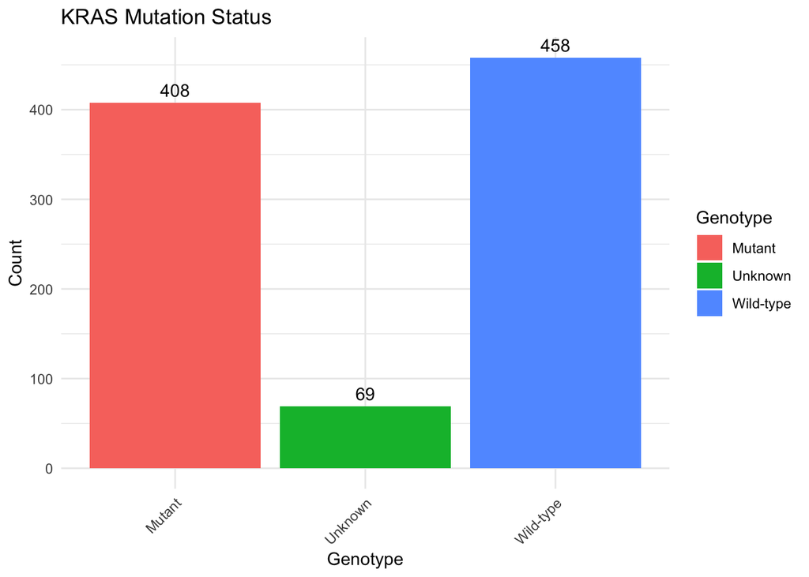

```r
d |> group_by(Genotype) |>
  summarize(Count = n()) |>
  ggplot(aes(x = Genotype, y = Count, fill = Genotype)) +
    geom_bar(stat = "identity") +
    labs(title = "KRAS Mutation Status", x = "Genotype", y = "Count") +
    theme_minimal() +
    theme(axis.text.x = element_text(angle = 45, hjust = 1)) +
    geom_text(aes(label = Count), vjust = -0.5)
```

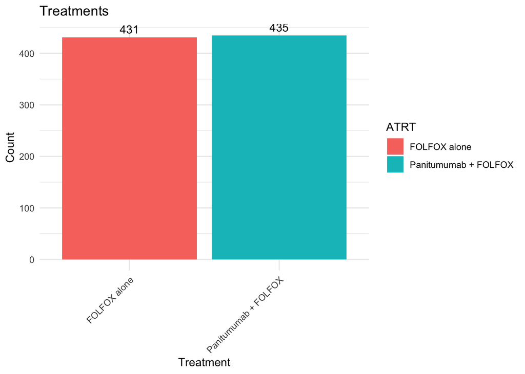

```r
d |>
    filter(Genotype != "Unknown") |> #ignore unknown genotypes
    group_by(ATRT) |>
    summarize(Count = n()) |>
    ggplot(aes(x = ATRT, y = Count, fill = ATRT)) +
    geom_bar(stat = "identity") +
    labs(title = "Treatments", x = "Treatment", y = "Count") +
    theme_minimal() +
    theme(axis.text.x = element_text(angle = 45, hjust = 1)) +
    geom_text(aes(label = Count), vjust = -0.5)
```

should we include predictive/ prognostic analysis done in HW2 to show where we’re picking up from? we know from HW2 that genotype is prognostic but not predictive (genotype impacts death outcome but this is not exacerbated by treatment). so we know that mutants are more likely to die (prognostic), but don’t know how many fewer days they will live. And we know that mutants are not more likely to die when being treated (predictive), but we do not know how much longer mutant & wild-types live while on treatment. We set out to answer these questions:

## Visualize average survival by genotype

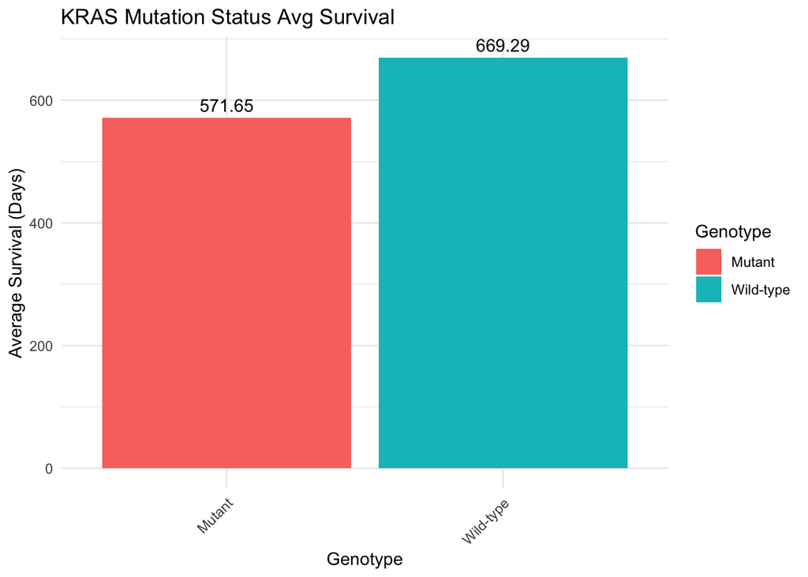

```r
source("plot_survival_days_genotype.R")

plot_survival_days_genotype(d)
```

## Analyze whether number of survival days differed by genotype

```r
source("test_survival_days_genotype.R")

test_survival_days_genotype(d)
```

```
    Two Sample t-test

data:  mutant_survival_days and wild_type_survival_days
t = -3.9039, df = 864, p-value = 0.000102
alternative hypothesis: true difference in means is not equal to 0
95 percent confidence interval:
 -146.73053  -48.55124
sample estimates:
mean of x mean of y
 571.6495  669.2904
```

Patients with a mutant genotype generally have 48 to 146 fewer days to live than those with a wild-type (p<0.05).

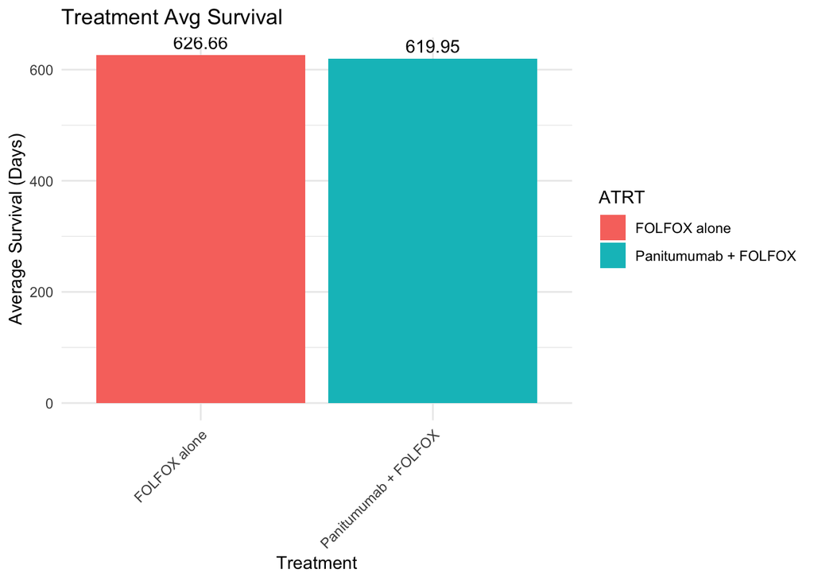

```r
source("plot_survival_days_treatment.R")

plot_survival_days_treatment(d)
```

## Analyze whether number of survival days differed by treatment

```r
source("test_survival_days_treatment.R")

test_survival_days_treatment(d)
```

```
    Two Sample t-test

data:  folfox_survival_days and folxfox_panitumumab_survival_days
t = 0.16625, df = 933, p-value = 0.868
alternative hypothesis: true difference in means is not equal to 0
95 percent confidence interval:
 -43.27879  51.28986
sample estimates:
mean of x mean of y
 618.5910  614.5855
```

Patients on one or both treatments do not have a different number of survival days (p>0.05).

## Does the combination of Genotype and Treatment Arm have a significant impact on patient survival outcomes?

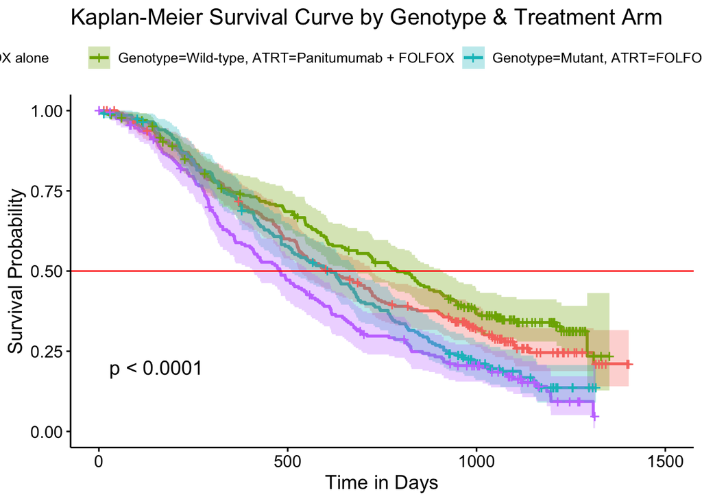

```r
# Filtering out unknown genotypes since these are not informative for this analysis
dcombo <- subset(d, Genotype != "Unknown")

dcombo$Genotype = factor(dcombo$Genotype, ordered = FALSE)
dcombo$Genotype = relevel(dcombo$Genotype, ref = "Wild-type")

dcombo$ATRT = factor(dcombo$ATRT, ordered = FALSE)
dcombo$ATRT = relevel(dcombo$ATRT, ref = "FOLFOX alone")

surv_plot <- ggsurvplot(
  survfit(Surv(DTHDY, DTH) ~ Genotype + ATRT, data = dcombo),
  data = dcombo,
  conf.int = TRUE,
  legend.title = "Genotype & ATRT",
  title = "Kaplan-Meier Survival Curve by Genotype & Treatment Arm",
  xlab = "Time in Days",
  ylab = "Survival Probability",
  pval = TRUE
)

surv_plot$plot + geom_hline(yintercept = 0.5, col = 'red')
```

Here we can see the following:

- There are some statistically significant interactions with p < 0.0001 although it is not specified what those interactions are.
- Subjects with a “Wild-type” genotype generally show higher survival rates over time.
- Subjects with a “Mutant” genotype generally show lower survival rates over time.
- If a subject has the “Wild-type” genotype, they may have an improved survival rate if they receive ‘Panitumumab+FOLFOX’ instead of ‘FOLFOX alone’
- If a subject has the “Mutant” genotype, they may have an improved survival rate if they receive ‘FOLFOX alone’ instead of ‘Panitumumab+FOLFOX’

##“Does the presence of KRAS mutations significantly impact the survival outcomes of metastatic colorectal cancer patients receiving different treatment regimens, specifically Panitumumab in combination with FOLFOX and FOLFOX alone?”

The Kaplan-Meier curve assesses whether there are significant differences in survival times among different genotypic groups .

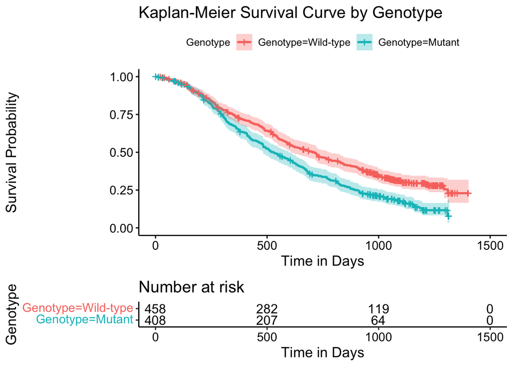

```r
ggsurvplot(
  survfit(Surv(DTHDY, DTH) ~ Genotype, data = dcombo),
  data = dcombo,
  conf.int = TRUE,
  legend.title = "Genotype",
  title = "Kaplan-Meier Survival Curve by Genotype",
  xlab = "Time in Days",
  ylab = "Survival Probability",
  risk.table = TRUE
)
```

```r
summary(coxph(Surv(dcombo$DTHDY, dcombo$DTH) ~ dcombo$Genotype))
```

```
Call:
coxph(formula = Surv(dcombo$DTHDY, dcombo$DTH) ~ dcombo$Genotype)

  n= 866, number of events= 633

                         coef exp(coef) se(coef)     z Pr(>|z|)
dcombo$GenotypeMutant 0.39599   1.48585  0.07992 4.955 7.23e-07 ***
---
Signif. codes:  0 '***' 0.001 '**' 0.01 '*' 0.05 '.' 0.1 ' ' 1

                      exp(coef) exp(-coef) lower .95 upper .95
dcombo$GenotypeMutant     1.486      0.673      1.27     1.738

Concordance= 0.543  (se = 0.011 )
Likelihood ratio test= 24.54  on 1 df,   p=7e-07
Wald test            = 24.55  on 1 df,   p=7e-07
Score (logrank) test = 24.87  on 1 df,   p=6e-07
```

Patients with the “Mutant” genotype have a lower chance of survival compared to those with the “Wild-type” genotype, as indicated by the positive coefficient and the significant log-rank test.

## Are there differences in the occurrence of adverse events between patients receiving Panitumumab in combination with FOLFOX and those receiving FOLFOX alone?

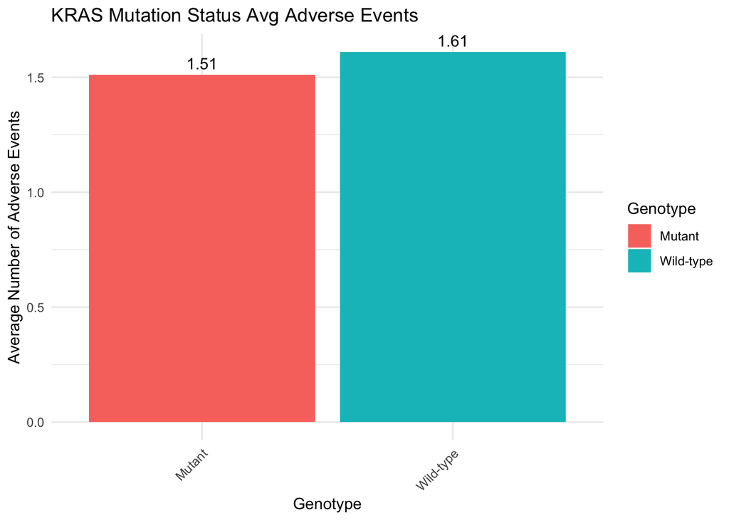

```r
source("plot_adverse_events_genotype.R")

plot_adverse_events_genotype(d)
```

```r
source("test_adverse_events_genotype.R")

test_adverse_events_genotype(d)
```

```
    Two Sample t-test

data:  mutant_adverse_events and wild_type_adverse_events
t = -0.78763, df = 864, p-value = 0.4311
alternative hypothesis: true difference in means is not equal to 0
95 percent confidence interval:
 -0.3479129  0.1486450
sample estimates:
mean of x mean of y
 1.507353  1.606987
```

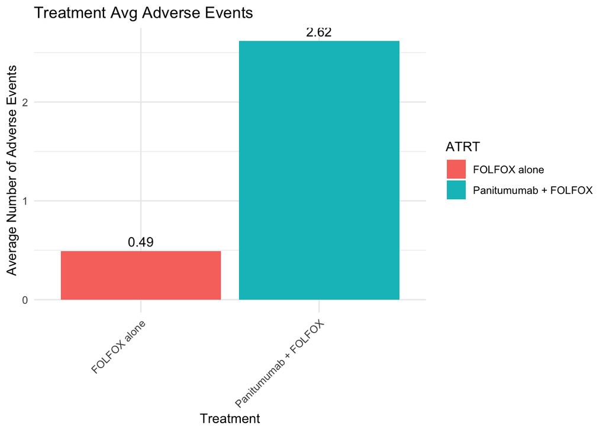

```r
source("plot_adverse_events_treatment.R")

plot_adverse_events_treatment(d)
```

```r
source("test_adverse_events_treatment.R")

test_adverse_events_treatment(d)
```

```
    Two Sample t-test

data:  folfox_adverse_events and folxfox_panitumumab_adverse_events
t = -21.443, df = 933, p-value < 2.2e-16
alternative hypothesis: true difference in means is not equal to 0
95 percent confidence interval:
 -2.314831 -1.926636
sample estimates:
mean of x mean of y
 0.496788  2.617521
```

Wild-type and mutant genotypes do not have different numbers of adverse events during the trial (p>0.05). However, we did find that patients taking Folfox alone had an average of 2 fewer adverse events than patients taking both Folfox combined with Panitumumab (p<0.05).

Do you need to keep any of the following code/ analysis?

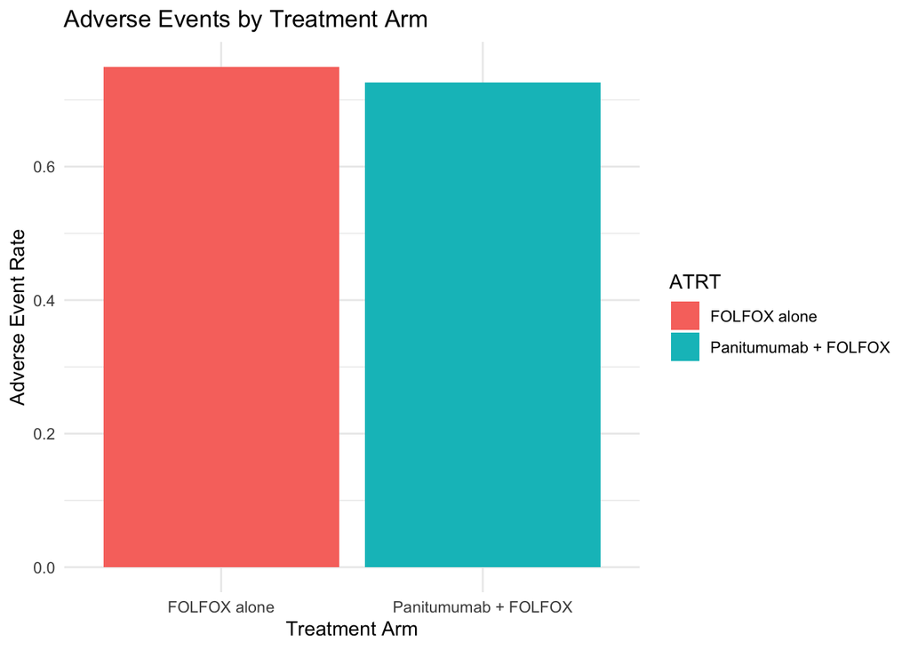

```r
# Example code
adverse_events <- d %>%
  group_by(ATRT) %>%
  # NOTE: Not sure if this should be 1 or 0
  summarize(AdverseEventRate = mean(DTH == "1", na.rm = TRUE))

ggplot(adverse_events, aes(x = ATRT, y = AdverseEventRate, fill = ATRT)) +
  geom_bar(stat = "identity") +
  labs(title = "Adverse Events by Treatment Arm", x = "Treatment Arm", y = "Adverse Event Rate") +
  theme_minimal()
```

```r
# Example code with statistical test
adverse_events <- d %>%
  group_by(ATRT) %>%
  summarize(AdverseEventRate = mean(DTH == "1", na.rm = TRUE))

# Create a contingency table
contingency_table <- table(d$DTH == "1", d$ATRT)

# Perform chi-squared test
chi_squared_test <- chisq.test(contingency_table)

# Print the test results
print(chi_squared_test)
```

```
    Pearson's Chi-squared test with Yates' continuity correction

data:  contingency_table
X-squared = 0.52449, df = 1, p-value = 0.4689
```

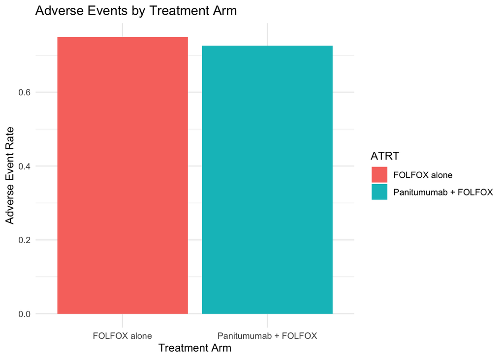

```r
# Plot the bar chart
ggplot(adverse_events, aes(x = ATRT, y = AdverseEventRate, fill = ATRT)) +
  geom_bar(stat = "identity") +
  labs(
    title = "Adverse Events by Treatment Arm",
    x = "Treatment Arm",
    y = "Adverse Event Rate"
  ) +
  theme_minimal()
```

**Are there significant differences in the survival distribution over time between different genotypes?** This plot should be considered part of the analysis, but merely exploratory

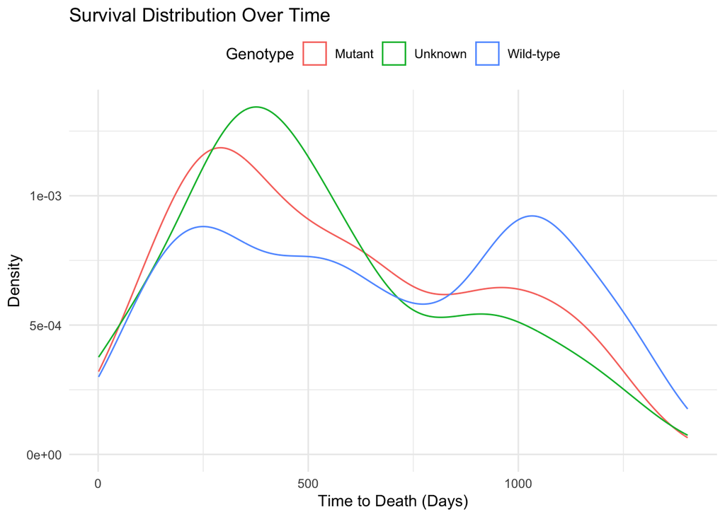

```r
ggplot(d, aes(x = DTHDY, color = Genotype)) +
  theme_minimal() +
  geom_density() +
  labs(title = "Survival Distribution Over Time", x = "Time to Death (Days)", y = "Density") +
  theme(legend.position = "top")
```

Are there significant differences in the survival distribution over time between different genotypes? (think this analysis piece is covered by the t-test, but I included the graph in the exploratory analysis)

Hypothesis: Null Hypothesis (H0): There is no significant difference in the survival distribution over time among different genotypes. Alternative Hypothesis (H1): There are significant differences in the survival distribution over time among different genotypes.

```r
surv_diff_genotype <- survdiff(Surv(DTHDY, DTH) ~ Genotype, data = d)
print(surv_diff_genotype)
```

```
Call:
survdiff(formula = Surv(DTHDY, DTH) ~ Genotype, data = d)

                     N Observed Expected (O-E)^2/E (O-E)^2/V
Genotype=Mutant    408      330    274.4      11.3     18.86
Genotype=Unknown    69       57     42.6       4.9      5.25
Genotype=Wild-type 458      303    373.1      13.2     28.97

 Chisq= 29.7  on 2 degrees of freedom, p= 4e-07
```

Hypothesis: Null Hypothesis (H0): The treatment arm does not significantly influence the survival distribution over time within each genotype. Alternative Hypothesis (H1): The treatment arm significantly influences the survival distribution over time within each genotype.

```r
surv_diff_treatment <- survdiff(Surv(DTHDY, DTH) ~ ATRT, data = d)
print(surv_diff_treatment)
```

```
Call:
survdiff(formula = Surv(DTHDY, DTH) ~ ATRT, data = d)

                            N Observed Expected (O-E)^2/E (O-E)^2/V
ATRT=FOLFOX alone         467      350      346    0.0484    0.0973
ATRT=Panitumumab + FOLFOX 468      340      344    0.0486    0.0973

 Chisq= 0.1  on 1 degrees of freedom, p= 0.8
```